# GPU OPTIMIZATION

```python
print(top_rated_books[['bookTitle', 'average_rating', 'rating_count']])
```

```
                                           bookTitle  average_rating  \
0  The Rise and Fall of the Third Reich - 2 Volum...        5.000000
1               The Rise and Fall on the Third Reich        5.000000
2                                  The Little Prince        4.944444
3  Narrative of the Life of Frederick Douglass, a...        4.941176
4  The Importance of Being Earnest and Related Wr...        4.909091
5  The Importance of Being Earnest [With Biograph...        4.909091
6                  The Lord of the Rings - Boxed Set        4.896552
7                           A Tree Grows in Brooklyn        4.894737
8  Six Days of War: June 1967 and the Making of t...        4.888889
9                    The Importance of Being Earnest        4.882353

   rating_count
0            13
1            11
2            18
3            17
4            11
5            11
6            29
7            19
8             9
9            17
```

correlation between Number of ratings and avarage ratings

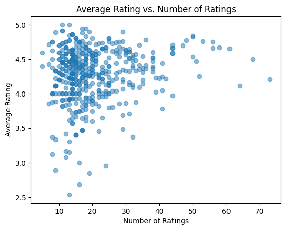

```python
plt.scatter(popular_books['rating_count'], popular_books['average_rating'], alpha=0.5)
plt.title('Average Rating vs. Number of Ratings')
plt.xlabel('Number of Ratings')
plt.ylabel('Average Rating')
plt.show()
```

timebase analysis

```python
df['timestamp'] = pd.to_datetime(df['timestamp'])
df['year'] = df['timestamp'].dt.year
```

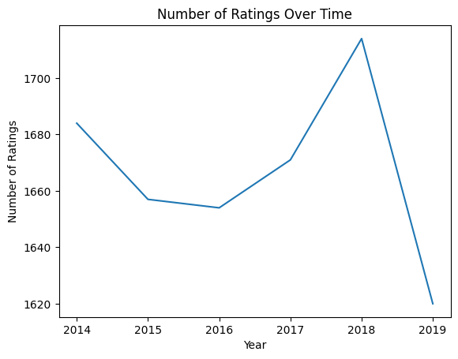

```python
ratings_per_year = df.groupby('year').size().reset_index(name='num_ratings')
plt.plot(ratings_per_year['year'], ratings_per_year['num_ratings'])
plt.title('Number of Ratings Over Time')
plt.xlabel('Year')
plt.ylabel('Number of Ratings')
plt.show()
```

Heatmap of user-book interaction

```python
user_book_matrix = df.pivot_table(index='userID', columns='bookID', values='rating')
```

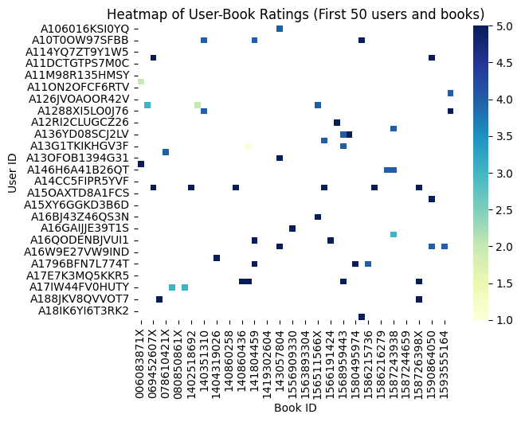

```python
import seaborn as sns

# Select a subset for visualization (e.g., first 50 users and books)
subset = user_book_matrix.iloc[:50, :50]
sns.heatmap(subset, cmap='YlGnBu')
plt.title('Heatmap of User-Book Ratings (First 50 users and books)')
plt.xlabel('Book ID')
plt.ylabel('User ID')
plt.show()
```

Genre analysis

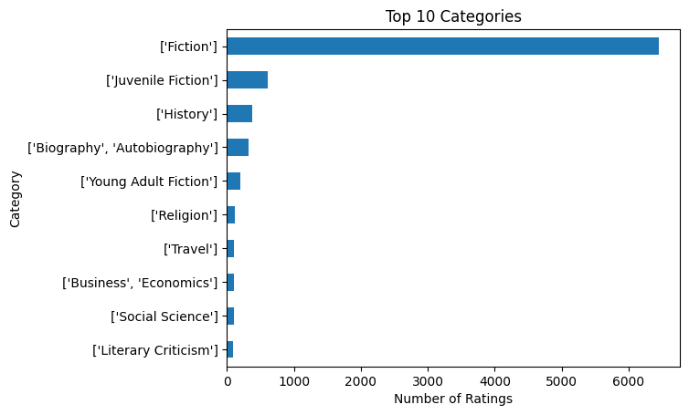

```python
genre_counts = df['bookCategory'].value_counts().reset_index()
genre_counts.columns = ['category', 'count']
genre_counts.head(10).plot(kind='barh', x='category', y='count', legend=False)
plt.title('Top 10 Categories')
plt.xlabel('Number of Ratings')
plt.ylabel('Category')
plt.gca().invert_yaxis()
plt.show()
```

word cloud of book titles

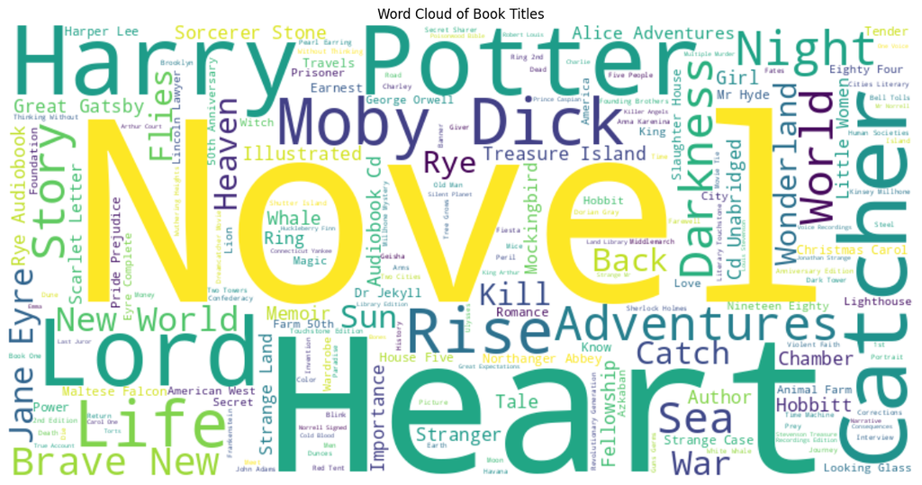

```python
from wordcloud import WordCloud

text = ' '.join(df['bookTitle'].dropna().tolist())
wordcloud = WordCloud(width=800, height=400, background_color='white').generate(text)

plt.figure(figsize=(15, 7.5))
plt.imshow(wordcloud, interpolation='bilinear')
plt.axis('off')
plt.title('Word Cloud of Book Titles')
plt.show()
```

user-rating patters

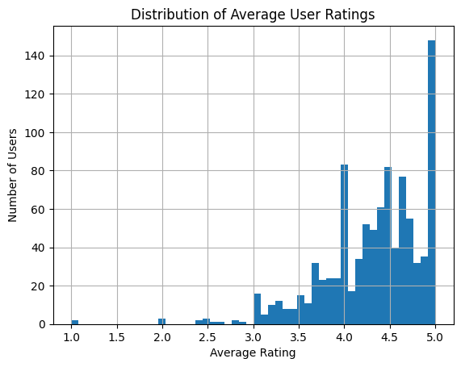

```python
avg_user_ratings = df.groupby('userID')['rating'].mean().reset_index(name='average_rating')
avg_user_ratings['average_rating'].hist(bins=50)
plt.title('Distribution of Average User Ratings')
plt.xlabel('Average Rating')
plt.ylabel('Number of Users')
plt.show()
```

# Tags building

```python
df.head(2)
```

|  | userID | canonical_book_id | userName | bookID | rating | bookTitle | bookAuthor | bookCategory | bookPublisher | description | image | Title | authors | publishedDate | Price | publisher | categories | timestamp | rating_count | rated_books_count |
| --- | --- | --- | --- | --- | --- | --- | --- | --- | --- | --- | --- | --- | --- | --- | --- | --- | --- | --- | --- | --- |
| 0 | A2E9Q3T876TQ6C | 2439 | Susie Morris "Book Junkie" | B000IA68SU | 4 | London Bridges | James Patterson | ['Fiction'] | Little, Brown | in broad desert daylight, a mysterious platoon... | http://books.google.com/books/content?id=dRWnU... | london bridges | james patterson | 2004 | 38.66 | Little, Brown | fiction | 11/1/2017 | 19 | 9 |
| 1 | A1L43KWWR05PCS | 3948 | Lawyeraau | B000HKRJDE | 5 | The Stranger Beside Me | Ann Rule | ['True Crime'] | W. W. Norton & Company | from the perspective of the former policewoman... | http://books.google.com/books/content?id=ADDtz... | stranger beside | ann rule | 2000 | 13.36 | W. W. Norton & Company | true crime | 2/24/2014 | 14 | 19 |

```python
import spacy
from spacy.lang.en.stop_words import STOP_WORDS
import re

nlp = spacy.load('en_core_web_sm')

# Function to expand common abbreviations in titles, publishers, etc.
def expand_abbreviation(text):
    abbreviations = {

        "intl": "international",
        "inc": "incorporated",
        "ltd": "limited",
        "co": "company",
        "sci-fi": "science fiction",

    }
    for abbr, expanded in abbreviations.items():
        text = re.sub(r'\b' + re.escape(abbr) + r'\b', expanded, text)
    return text

# Define separate cleaning functions for each column type
def clean_description(text):
    if not isinstance(text, str):
        return ''
    # Lowercase conversion
    text = text.lower()
    # Tokenize and remove stop words, punctuation, special characters
    doc = nlp(text)
    tokens = [
        token.lemma_ for token in doc
        if not token.is_stop and not token.is_punct and not token.like_num and len(token) > 2
    ]
    cleaned_text = ' '.join(tokens)
    return cleaned_text

def clean_publisher(text):
    if not isinstance(text, str):
        return ''
    # Lowercase and expand abbreviations
    text = text.lower()
    text = expand_abbreviation(text)
    # Tokenize and remove stop words, punctuation, special characters
    doc = nlp(text)
    tokens = [
        token.lemma_ for token in doc
        if not token.is_punct and not token.like_num
    ]
    cleaned_text = ' '.join(tokens)
    return cleaned_text

def clean_categories(text):
    if not isinstance(text, str):
        return ''
    # Split categories based on delimiter and clean whitespace
    tokens = text.split(",")  # Assume categories are comma-separated
    tokens = [token.strip().lower() for token in tokens if token.strip()]
    # Optionally, you can further process tokens (e.g., lemmatization)
    cleaned_text = ' '.join(tokens)
    return cleaned_text

def clean_authors(text):
    if not isinstance(text, str):
        return ''
    # Lowercase and expand abbreviations if needed
    text = text.lower()
    text = expand_abbreviation(text)
    # Tokenize and remove stop words, punctuation, special characters
    doc = nlp(text)
    tokens = [
        token.lemma_ for token in doc
        if not token.is_punct and not token.like_num
    ]
    cleaned_text = ' '.join(tokens)
    return cleaned_text

# Apply column-specific cleaning functions
df['description'] = df['description'].apply(clean_description)
df['publisher'] = df['publisher'].apply(clean_publisher)
df['categories'] = df['categories'].apply(clean_categories)
df['authors'] = df['authors'].apply(clean_authors)

# Example of how the dataset could be cleaned for tokenization and text normalization
df.head(2)  # This will show the cleaned dataset for review
```

|  | userID | canonical_book_id | userName | bookID | rating | bookTitle | bookAuthor | bookCategory | bookPublisher | description | image | Title | authors | publishedDate | Price | publisher | categories | timestamp | rating_count | rated_books_count |
| --- | --- | --- | --- | --- | --- | --- | --- | --- | --- | --- | --- | --- | --- | --- | --- | --- | --- | --- | --- | --- |
| 0 | A2E9Q3T876TQ6C | 2439 | Susie Morris "Book Junkie" | B000IA68SU | 4 | London Bridges | James Patterson | ['Fiction'] | Little, Brown | broad desert daylight mysterious platoon soldi... | http://books.google.com/books/content?id=dRWnU... | london bridges | james patterson | 2004 | 38.66 | little brown | fiction | 11/1/2017 | 19 | 9 |
| 1 | A1L43KWWR05PCS | 3948 | Lawyeraau | B000HKRJDE | 5 | The Stranger Beside Me | Ann Rule | ['True Crime'] | W. W. Norton & Company | perspective policewoman crime writer unknowe p... | http://books.google.com/books/content?id=ADDtz... | stranger beside | ann rule | 2000 | 13.36 | w. w. norton company | true crime | 2/24/2014 | 14 | 19 |

```python
columns_to_combine = ['description', 'Title', 'authors', 'publisher', 'categories']

# Combine the columns into a new 'combined_text' column
df['tags'] = df[columns_to_combine].agg(' '.join, axis=1)

# Remove extra whitespace
df['tags'] = df['tags'].str.replace('\s+', ' ', regex=True).str.strip()

# Display the DataFrame to verify
print(df[['tags']].head())
```

```
                                                tags
0  broad desert daylight mysterious platoon soldi...
1  perspective policewoman crime writer unknowe p...
2  new york times good seller grisham return cour...
3  begin journey middle earth inspiration upcomin...
4  timely update jane austen pride prejudice nati...
```

# Rating Based Recommendations

```python
df.columns
```

[output not shown]

**Weighted rating formula for most popular books with highest rating**

`Weighted Rating (WR) = (v/(v+m)) * R + (m/(v+m)) * C`

Where:

- R = average rating for the book
- v = number of ratings for the book
- m = minimum number of ratings required to be considered
- C = the mean rating across all books

```python
# Calculate the average rating for each book
avrg_ratings = df.groupby('bookID')['rating'].mean()

# Merge the results back to the original dataframe
df = df.merge(avrg_ratings.rename('average_ratings'), on='bookID', how='left')
```

```python
# Calculate the overall average rating for all books (C)
C = df['average_ratings'].mean()
```

[output not shown]

```python
# Set the minimum number of ratings required to be considered (m)
m = df['rating_count'].quantile(0.90)  # For example, taking the top 10% as the threshold


# Apply the weighted rating formula to get the weighted score (WR)
df['weighted_rating'] = (df['rating_count'] / (df['rating_count'] + m)) * df['average_ratings'] + (m / (df['rating_count'] + m)) * C

# Sort the books by weighted rating and drop duplicates
rating_based_recommendations = df.sort_values(by='weighted_rating', ascending=False).drop_duplicates(subset='bookID').head(10)
# Select and display the relevant columns
final_columns = ['bookTitle','bookAuthor','bookCategory', 'Price', 'weighted_rating', 'image' ]
rating_based_recommendations= rating_based_recommendations[final_columns]
```

**Breakdown of the Code:**

- rating_count: Counts how many ratings each book received.
- average_ratings: Calculates the average rating of each book.
- C: The global average rating for all books.
- m: The minimum number of ratings needed to give more confidence to a rating (set at the 90th percentile of the rating counts).
- weighted_rating: Uses the weighted formula to give a better ranking to books that have more ratings and a good rating score.
- rating_based_recommendations: The books are sorted based on the weighted rating, and then the top 10 are selected.

```python
print("Rating Base Recommendation System: ")
rating_based_recommendations.head(10)
```

```
Rating Base Recommendation System:
```

|  | bookTitle | bookAuthor | bookCategory | Price | weighted_rating | image |
| --- | --- | --- | --- | --- | --- | --- |
| 7552 | Night | Clement Moore | ['Juvenile Fiction'] | 40.68 | 4.600841 | http://books.google.com/books/content?id=LSSyD... |
| 3325 | George Orwell 1984 | George Orwell | ['Fiction'] | 5.13 | 4.593366 | http://books.google.com/books/content?id=PEpoE... |
| 2456 | Nineteen Eighty-Four | George Orwell | ['Totalitarianism'] | 24.49 | 4.582728 | http://books.google.com/books/content?id=h7BUN... |
| 544 | Moby-Dick: Or, the Whale | Herman Melville | ['Fiction'] | 10.88 | 4.574315 | http://books.google.com/books/content?id=xJFPE... |
| 1209 | 1984 | George Orwell | ['Fiction'] | 16.74 | 4.554396 | http://books.google.com/books/content?id=gTx1A... |
| 1937 | The Hobbit | J. R. R. Tolkien | ['Juvenile Fiction'] | 34.80 | 4.551917 | http://books.google.com/books/content?id=LLSpn... |
| 7633 | The Lord of the Rings - Boxed Set | j.r.r. Tolkien | ['Young Adult Fiction'] | 6.87 | 4.544882 | http://books.google.com/books/content?id=CixXE... |
| 322 | John Adams | David McCullough | ['Biography', 'Autobiography'] | 29.94 | 4.522205 | http://books.google.com/books/content?id=GHMnz... |
| 6252 | Harry Potter and the Sorcerer's Stone | J. K. Rowling | ['Juvenile Fiction'] | 30.54 | 4.517416 | http://books.google.com/books/content?id=HksgD... |
| 474 | Harry Potter and the Chamber of Secrets | J. K. Rowling | ['Juvenile Fiction'] | 22.73 | 4.514026 | http://books.google.com/books/content?id=nmXTy... |

# Content Based Recommendations

```python
df=pd.read_csv('/content/drive/MyDrive/book-rec-collab//newwww.csv')
```

```python
df.columns
```

```
Index(['userID', 'canonical_book_id', 'userName', 'bookID', 'rating',
       'bookTitle', 'bookAuthor', 'bookCategory', 'bookPublisher',
       'description', 'image', 'Title', 'authors', 'publishedDate', 'Price',
       'publisher', 'categories', 'timestamp', 'rating_count',
       'rated_books_count', 'tags', 'average_ratings', 'weighted_rating'],
      dtype='object')
```

```python
dfc=df.copy()
```

```python
from sklearn.feature_extraction.text import TfidfVectorizer
from sklearn.metrics.pairwise import cosine_similarity
import string
from nltk.corpus import stopwords
import nltk

nltk.download('stopwords')
```

```
True
```

```python
# Compute TF-IDF and cosine similarity
def compute_similarity(text_data):
    tfidf_vectorizer = TfidfVectorizer(stop_words='english')
    tfidf_matrix_content = tfidf_vectorizer.fit_transform(text_data)
    cosine_similarities_content = cosine_similarity(tfidf_matrix_content, tfidf_matrix_content)
    return cosine_similarities_content
```

```python
cosine_similarities_content = compute_similarity(df['tags'])
```

```python
cosine_similarities_content
```

```
array([[1.        , 0.0136235 , 0.01225344, ..., 0.05493275, 0.03175353,
        0.01076612],
       [0.0136235 , 1.        , 0.01313919, ..., 0.        , 0.04691696,
        0.01467168],
       [0.01225344, 0.01313919, 1.        , ..., 0.01717518, 0.0294293 ,
        0.03010292],
       ...,
       [0.05493275, 0.        , 0.01717518, ..., 1.        , 0.01795643,
        0.04391316],
       [0.03175353, 0.04691696, 0.0294293 , ..., 0.01795643, 1.        ,
        0.01999064],
       [0.01076612, 0.01467168, 0.03010292, ..., 0.04391316, 0.01999064,
        1.        ]])
```

```python
stop_words = set(stopwords.words('english'))
# Text preprocessing function
def preprocess_text(text):
    # Lowercase
    text = text.lower()
    # Remove punctuation
    text = text.translate(str.maketrans('', '', string.punctuation))
    # Remove stopwords
    text = ' '.join([word for word in text.split() if word not in stop_words])
    return text
```

```python
def contentBased_recommendations(title, cosine_similarities, df, top_n=10):
    # Preprocess the input title
    input_title = preprocess_text(title)


    if not input_title:
        print(f"Title '{title}' not found in the dataset.")
        return pd.DataFrame()

    # Create a temporary column for processed titles
    df['processed_title'] = df['bookTitle'].apply(preprocess_text)

    # Find the index of the input title
    idx_list = df[df['processed_title'] == input_title].index.tolist()
    if not idx_list:
        print(f"Title '{title}' not found in the dataset.")
        df.drop('processed_title', axis=1, inplace=True)
        return pd.DataFrame()

    # use the first occurrence
    idx = idx_list[0]

    # Get similarity scores for all books
    sim_scores = list(enumerate(cosine_similarities[idx]))

    # Exclude the book itself and any other books with the same normalized title
    sim_scores = [score for score in sim_scores if score[0] not in idx_list]

    # Sort the books based on similarity scores
    sim_scores = sorted(sim_scores, key=lambda x: x[1], reverse=True)

   # Keep track of unique book titles
    unique_titles = set()
    filtered_sim_scores = []
    for i, score in sim_scores:
        book_title = df.iloc[i]['Title']
        if book_title not in unique_titles:
            unique_titles.add(book_title)
            filtered_sim_scores.append((i, score))
        # Stop if we have enough recommendations
        if len(filtered_sim_scores) >= top_n:
            break

    # Get the indices and scores of the top_n unique similar books
    book_indices = [i for i, _ in filtered_sim_scores]
    similarity_scores = [score for _, score in filtered_sim_scores]

    # Get the recommended books with their scores
    recommendations = df.iloc[book_indices].copy()
    recommendations['score_content'] = similarity_scores

    # Drop the temporary column
    df.drop('processed_title', axis=1, inplace=True)

    return recommendations
```

**GET CONTENT_BASED RECOMMENDATIONS FOR A SPECIFIC BOOK**

```python
# Get recommendations as a DataFrame
title = 'The Hobbit'  # Replace with an actual title from your dataset
recommendations_df = contentBased_recommendations(title, cosine_similarities_content, df)

# Select desired columns
desired_columns = ['bookID','bookTitle','bookAuthor','categories', 'Price', 'weighted_rating', 'image']
recommendations_df = recommendations_df[desired_columns]

# Check if recommendations are found
if recommendations_df.empty:
    print(f"No recommendations found for '{title}'.")
else:
    # Display the DataFrame
    print(f"Recommendations for '{title}':")
      # Display up to 10 recommendations
    print(recommendations_df.head(10).to_string())
```

```
Recommendations for 'The Hobbit':
         bookID                                                         bookTitle                 bookAuthor           categories  Price  weighted_rating                                                                                                            image
509  B000GQK706                                 The Lord of the Rings - Boxed Set             j.r.r. Tolkien  young adult fiction   6.87         4.544882            http://books.google.com/books/content?id=CixXEAAAQBAJ&printsec=frontcover&img=1&zoom=1&source=gbs_api
28   B000Q08CDQ  Return of the King Being the Third Part of the Lord of the Rings           J. R. R. Tolkien              fiction  38.77         4.415748            http://books.google.com/books/content?id=1EcBuwAACAAJ&printsec=frontcover&img=1&zoom=1&source=gbs_api
108  B000NWU3I4  The Hobbitt, or There and Back Again; Illustrated by the Author.           J. R. R. Tolkien              fiction  39.31         4.512156            http://books.google.com/books/content?id=Wbm1mQEACAAJ&printsec=frontcover&img=1&zoom=1&source=gbs_api
430  B000I1V604                                   One Flew Over the Cuckoo's Nest                  Ken Kesey              fiction  15.80         4.399619  http://books.google.com/books/content?id=KhRvDQAAQBAJ&printsec=frontcover&img=1&zoom=1&edge=curl&source=gbs_api
12   B000JW6ZMG                        Travels With Charley, in Search of America             John Steinbeck               travel  11.95         4.302845  http://books.google.com/books/content?id=Rh6MDQAAQBAJ&printsec=frontcover&img=1&zoom=1&edge=curl&source=gbs_api
208   143057804                  The Shadow of the Wind Bestseller's Choice Audio          Carlos Ruiz Zafon              fiction   8.19         4.310096  http://books.google.com/books/content?id=GKlCDwAAQBAJ&printsec=frontcover&img=1&zoom=1&edge=curl&source=gbs_api
88   B000TNGU5M                                                             Night              Clement Moore     juvenile fiction  40.68         4.600841  http://books.google.com/books/content?id=LSSyDwAAQBAJ&printsec=frontcover&img=1&zoom=1&edge=curl&source=gbs_api
872  B0007GZPJI                                                 Lord of the Flies            William Golding              fiction  34.75         4.486095  http://books.google.com/books/content?id=r6eoCwAAQBAJ&printsec=frontcover&img=1&zoom=1&edge=curl&source=gbs_api
32   B0007C4L2Y                                        Lord of the Flies: A Novel            William Golding              fiction  31.27         4.339163  http://books.google.com/books/content?id=3C-4dsIGlEgC&printsec=frontcover&img=1&zoom=1&edge=curl&source=gbs_api
192  B000Q9I494                                Fellowship of the Ring 2nd Edition  John Ronald Reuel Tolkien    adventure stories  13.35         4.404953            http://books.google.com/books/content?id=5QRZ4z6A1WwC&printsec=frontcover&img=1&zoom=1&source=gbs_api
```

# Collaborative Filtering Recommendations

```python
df.columns
```

```
Index(['userID', 'canonical_book_id', 'userName', 'bookID', 'rating',
       'bookTitle', 'bookAuthor', 'bookCategory', 'bookPublisher',
       'description', 'image', 'Title', 'authors', 'publishedDate', 'Price',
       'publisher', 'categories', 'timestamp', 'rating_count',
       'rated_books_count', 'tags', 'average_ratings', 'weighted_rating'],
      dtype='object')
```

```python
from surprise import SVD, Dataset, Reader

def collaborative_filtering_recommendations(df, target_user_id, top_n=10):
    # Prepare the data
    reader = Reader(rating_scale=(df['rating'].min(), df['rating'].max()))
    data = Dataset.load_from_df(df[['userID', 'bookID', 'rating']], reader)
    trainset = data.build_full_trainset()

    # Build the model
    algo = SVD()
    algo.fit(trainset)

    # Get a list of all book IDs
    all_book_ids = df['bookID'].unique()

    # Predict ratings for all books not rated by the user
    user_rated_books = df[df['userID'] == target_user_id]['bookID'].unique()
    books_to_predict = [iid for iid in all_book_ids if iid not in user_rated_books]

    predictions = [algo.predict(target_user_id, iid) for iid in books_to_predict]

    # Get top N recommendations
    predictions.sort(key=lambda x: x.est, reverse=True)
    top_predictions = predictions[:top_n]
    top_book_ids = [pred.iid for pred in top_predictions]
    scores = [pred.est for pred in top_predictions]

    # Get book details
    recommendations = df[df['bookID'].isin(top_book_ids)].drop_duplicates('bookID')
    recommendations = recommendations[['bookID','bookTitle','bookAuthor','bookCategory', 'Price', 'weighted_rating', 'image']].copy()
    recommendations['score_collaborative'] = scores

    return recommendations
```

**COLLABORATIVE FILTERING TEST**

EVALUATION

```python
from surprise import Dataset, Reader, SVD
from surprise.model_selection import cross_validate, KFold
from collections import defaultdict

# Load data
reader = Reader(rating_scale=(df['rating'].min(), df['rating'].max()))
data = Dataset.load_from_df(df[['userID', 'bookID', 'rating']], reader)

# Define algorithm
algo = SVD()

# Step 3: Evaluate with RMSE and MAE using cross-validation
cv_results = cross_validate(algo, data, measures=['RMSE', 'MAE'], cv=5, verbose=True)
print("Average RMSE:", cv_results['test_rmse'].mean())
print("Average MAE:", cv_results['test_mae'].mean())

# Step 4: Compute Precision@K and Recall@K
def precision_recall_at_k(predictions, k=10, threshold=4.0):
    '''Return precision and recall at k metrics for each user.'''

    # Map the predictions to each user.
    user_est_true = defaultdict(list)
    for uid, iid, true_r, est, _ in predictions:
        user_est_true[uid].append((est, true_r))

    precisions = dict()
    recalls = dict()
    for uid, user_ratings in user_est_true.items():

        # Sort user ratings by estimated value
        user_ratings.sort(key=lambda x: x[0], reverse=True)

        # Number of relevant items
        n_rel = sum((true_r >= threshold) for (_, true_r) in user_ratings)

        # Number of recommended items in top k
        n_rec_k = sum((est >= threshold) for (est, _) in user_ratings[:k])

        # Number of relevant and recommended items in top k
        n_rel_and_rec_k = sum(((true_r >= threshold) and (est >= threshold))
                              for (est, true_r) in user_ratings[:k])

        # Precision@K: Proportion of recommended items that are relevant
        precisions[uid] = n_rel_and_rec_k / n_rec_k if n_rec_k != 0 else 0

        # Recall@K: Proportion of relevant items that are recommended
        recalls[uid] = n_rel_and_rec_k / n_rel if n_rel != 0 else 0

    return precisions, recalls

kf = KFold(n_splits=5)

precisions_list = []
recalls_list = []

for trainset, testset in kf.split(data):
    # Train the algorithm
    algo.fit(trainset)

    # Test the algorithm
    predictions = algo.test(testset)

    # Compute precision and recall
    precisions, recalls = precision_recall_at_k(predictions, k=10, threshold=4.0)

    # Average precision and recall for this fold
    precision = sum(prec for prec in precisions.values()) / len(precisions)
    recall = sum(rec for rec in recalls.values()) / len(recalls)

    precisions_list.append(precision)
    recalls_list.append(recall)

# Compute overall average precision and recall
avg_precision = sum(precisions_list) / len(precisions_list)
avg_recall = sum(recalls_list) / len(recalls_list)

print(f'Average Precision@10: {avg_precision:.4f}')
print(f'Average Recall@10: {avg_recall:.4f}')
```

```
Evaluating RMSE, MAE of algorithm SVD on 5 split(s).

                  Fold 1  Fold 2  Fold 3  Fold 4  Fold 5  Mean    Std
RMSE (testset)    0.8331  0.8352  0.8714  0.8753  0.8685  0.8567  0.0186
MAE (testset)     0.6303  0.6416  0.6622  0.6643  0.6589  0.6515  0.0132
Fit time          0.16    0.18    0.17    0.16    0.17    0.17    0.01
Test time         0.02    0.02    0.02    0.01    0.02    0.02    0.00
Average RMSE: 0.8566937497301146
Average MAE: 0.6514520143586314
Average Precision@10: 0.7846
Average Recall@10: 0.7792
```

TESTING

```python
target_user_id = 'AZSV99SDJC242'
top_n = 10
recommendations = collaborative_filtering_recommendations(df, target_user_id, top_n=top_n)
print(f"Top {top_n} recommendations for user {target_user_id}:")
recommendations
```

```
Top 10 recommendations for user AZSV99SDJC242:
```

|  | bookID | bookTitle | bookAuthor | bookCategory | Price | weighted_rating | image | score_collaborative |
| --- | --- | --- | --- | --- | --- | --- | --- | --- |
| 88 | B000TNGU5M | Night | Clement Moore | ['Juvenile Fiction'] | 40.68 | 4.600841 | http://books.google.com/books/content?id=LSSyD... | 4.797125 |
| 133 | B000N79NHQ | Animal Farm 50th Anniversary Edition | George Orwell | ['Fiction'] | 24.19 | 4.508823 | http://books.google.com/books/content?id=Ka5iF... | 4.770008 |
| 148 | B0006QSHNA | The Little Prince | Antoine De Saint-Exupery | ['Juvenile Fiction'] | 28.50 | 4.496394 | http://books.google.com/books/content?id=kwyOr... | 4.740082 |
| 194 | B000GROP62 | Nineteen Eighty-Four | George Orwell | ['Totalitarianism'] | 24.49 | 4.582728 | http://books.google.com/books/content?id=h7BUN... | 4.695052 |
| 201 | B000NWO8CG | A Tree Grows in Brooklyn | Betty Smith | ['Fiction'] | 26.99 | 4.488514 | http://books.google.com/books/content?id=Sn2Iy... | 4.627901 |
| 226 | B000NHNM3C | George Orwell 1984 | George Orwell | ['Fiction'] | 5.13 | 4.593366 | http://books.google.com/books/content?id=PEpoE... | 4.624520 |
| 321 | 446781819 | Gone With the Wind | Margaret Mitchell | ['Fiction'] | 34.16 | 4.489513 | http://books.google.com/books/content?id=01KdD... | 4.586702 |
| 713 | B000PR7VUK | Mayflower : A Story of Courage, Community, and... | Nathaniel Philbrick | ['History'] | 35.74 | 4.475020 | http://books.google.com/books/content?id=qk9AX... | 4.585254 |
| 903 | B000KJQ6PE | Jurassic Park | Michael Crichton | ['Fiction'] | 9.25 | 4.402990 | http://books.google.com/books/content?id=MNeEF... | 4.568832 |
| 917 | B000NQ8RZQ | Something Wicked This Way Comes | Ray Bradbury | ['Fiction'] | 32.38 | 4.392697 | http://books.google.com/books/content?id=uWc6D... | 4.565442 |

# Hybrid REcommendation

```python
def hybrid_recommendations(content_recs, collaborative_recs, df, content_weight=0.5, collaborative_weight=0.5, top_n=10):
    import pandas as pd

    # Merge recommendations on 'bookID'
    combined_recs = pd.merge(
        content_recs[['bookID', 'score_content']],
        collaborative_recs[['bookID', 'score_collaborative']],
        on='bookID',
        how='outer'
    )

    # Fill NaN scores with zeros
    combined_recs['score_content'] = combined_recs['score_content'].fillna(0)
    combined_recs['score_collaborative'] = combined_recs['score_collaborative'].fillna(0)

    # Compute weighted sum of scores
    combined_recs['score_hybrid'] = (
        content_weight * combined_recs['score_content'] +
        collaborative_weight * combined_recs['score_collaborative']
    )

    # Remove any duplicates based on 'bookID'
    combined_recs = combined_recs.drop_duplicates(subset='bookID')

    # Merge with the main DataFrame to get item attributes
    combined_recs = pd.merge(
        combined_recs,
        df[['bookID', 'bookTitle', 'bookAuthor', 'bookCategory', 'Price', 'weighted_rating', 'image']],
        on='bookID',
        how='left'
    )

    # Remove any duplicates again after merging, if necessary
    combined_recs = combined_recs.drop_duplicates(subset='bookID')

    # Sort the recommendations based on the hybrid score
    combined_recs = combined_recs.sort_values(by='score_hybrid', ascending=False)

    # Return the top_n recommendations
    hybrid_top_n = combined_recs.head(top_n).reset_index(drop=True)

    # Rearrange columns if necessary
    columns_order = ['bookID', 'bookTitle', 'bookAuthor', 'bookCategory', 'Price',
                     'weighted_rating', 'image', 'score_hybrid', 'score_content', 'score_collaborative']
    hybrid_top_n = hybrid_top_n[columns_order]

    return hybrid_top_n
```

```python
df.columns
```

```
Index(['userID', 'canonical_book_id', 'userName', 'bookID', 'rating',
       'bookTitle', 'bookAuthor', 'bookCategory', 'bookPublisher',
       'description', 'image', 'Title', 'authors', 'publishedDate', 'Price',
       'publisher', 'categories', 'timestamp', 'rating_count',
       'rated_books_count', 'tags', 'average_ratings', 'weighted_rating'],
      dtype='object')
```

USAGE OF HYBRID RECOMMENDATION

```python
# Content-based recommendations
content_recs = contentBased_recommendations(
    title='The Hobbit',
    cosine_similarities=cosine_similarities_content,
    df=df,
    top_n=100  # Increase to ensure enough unique recommendations
)

# Collaborative filtering recommendations
collaborative_recs = collaborative_filtering_recommendations(
    df=df,
    target_user_id='A2EWCVGOTTPFAZ',  # Replace with the actual user ID
    top_n=100  # Increase to ensure enough unique recommendations
)

# Generate hybrid recommendations
hybrid_recs = hybrid_recommendations(
    content_recs=content_recs,
    collaborative_recs=collaborative_recs,
    df=df,
    content_weight=0.5,
    collaborative_weight=0.5,
    top_n=10  # Final number of unique recommendations to return
)

# Display the recommendations
hybrid_recs.head(5)
```

|  | bookID | bookTitle | bookAuthor | bookCategory | Price | weighted_rating | image | score_hybrid | score_content | score_collaborative |
| --- | --- | --- | --- | --- | --- | --- | --- | --- | --- | --- |
| 0 | B000Q08CDQ | Return of the King Being the Third Part of the... | J. R. R. Tolkien | ['Fiction'] | 38.77 | 4.415748 | http://books.google.com/books/content?id=1EcBu... | 2.591111 | 0.182221 | 5.000000 |
| 1 | B000NWU3I4 | The Hobbitt, or There and Back Again; Illustra... | J. R. R. Tolkien | ['Fiction'] | 39.31 | 4.512156 | http://books.google.com/books/content?id=Wbm1m... | 2.579770 | 0.159540 | 5.000000 |
| 2 | B000GQK706 | The Lord of the Rings - Boxed Set | j.r.r. Tolkien | ['Young Adult Fiction'] | 6.87 | 4.544882 | http://books.google.com/books/content?id=CixXE... | 2.562956 | 0.195080 | 4.930832 |
| 3 | B000TNGU5M | Night | Clement Moore | ['Juvenile Fiction'] | 40.68 | 4.600841 | http://books.google.com/books/content?id=LSSyD... | 2.543361 | 0.086721 | 5.000000 |
| 4 | B000Q9I494 | Fellowship of the Ring 2nd Edition | John Ronald Reuel Tolkien | ['Adventure Stories'] | 13.35 | 4.404953 | http://books.google.com/books/content?id=5QRZ4... | 2.541698 | 0.083396 | 5.000000 |

```python
# Content-based recommendations
content_recs = contentBased_recommendations(
    title='The Great Gatsby',
    cosine_similarities=cosine_similarities_content,
    df=df,
    top_n=100  # Increase to ensure enough unique recommendations
)

# Collaborative filtering recommendations
collaborative_recs = collaborative_filtering_recommendations(
    df=df,
    target_user_id='A2ODBHT4URXVXQ',  # Replace with the actual user ID
    top_n=100  # Increase to ensure enough unique recommendations
)

# Generate hybrid recommendations
hybrid_recs = hybrid_recommendations(
    content_recs=content_recs,
    collaborative_recs=collaborative_recs,
    df=df,
    content_weight=0.5,
    collaborative_weight=0.5,
    top_n=10  # Final number of unique recommendations to return
)

# Display the recommendations
hybrid_recs.head(5)
```

|  | bookID | bookTitle | bookAuthor | bookCategory | Price | weighted_rating | image | score_hybrid | score_content | score_collaborative |
| --- | --- | --- | --- | --- | --- | --- | --- | --- | --- | --- |
| 0 | 623013754 | The Importance of Being Earnest | Oscar Wilde | ['Fiction'] | 8.47 | 4.471744 | http://books.google.com/books/content?id=hlbvD... | 2.559951 | 0.280187 | 4.839714 |
| 1 | B000PRXGLS | The Adventures of Sherlock Holmes: Sherlock Ho... | Arthur Conan Doyle | ['Criminal Investigation'] | 46.44 | 4.436888 | http://books.google.com/books/content?id=tBasG... | 2.553228 | 0.106455 | 5.000000 |
| 2 | B0007BY9UY | Homage to Catalonia | George Orwell | ['Biography', 'Autobiography'] | 30.72 | 4.442714 | http://books.google.com/books/content?id=Ybr7D... | 2.542852 | 0.203633 | 4.882071 |
| 3 | B000KK2SLE | For Whom the Bell Tolls | Ernest Hemingway | ['Fiction'] | 28.39 | 4.386706 | http://books.google.com/books/content?id=-08IV... | 2.521841 | 0.043683 | 5.000000 |
| 4 | B000TNGU5M | Night | Clement Moore | ['Juvenile Fiction'] | 40.68 | 4.600841 | http://books.google.com/books/content?id=LSSyD... | 2.521465 | 0.046887 | 4.996043 |

Evaluating Content-Based Recommendations

```python
from sklearn.metrics import precision_score, recall_score
```

```python
def evaluate_content_based(df, target_book_id, content_recs, top_n=10):
    # Strip any leading or trailing spaces in the column names
    df.columns = df.columns.str.strip()

    # Get actual similar books based on your logic
    actual_similar_books = []  # Define how to get similar books for target_book_id

    # Here, let's assume you determine actual similar books based on the same category
    target_book_category = df[df['bookID'] == target_book_id]['bookCategory'].values
    if len(target_book_category) == 0:
        print(f"Warning: Book ID {target_book_id} not found.")
        return None, None

    target_book_category = target_book_category[0]  # Get the first matching category
    actual_similar_books = df[df['bookCategory'].str.contains(target_book_category, na=False)]['bookID'].tolist()

    # Get the recommended book IDs
    recommended_books = content_recs['bookID'].tolist()[:top_n]

    # Create binary lists for precision and recall calculation
    y_true = [1 if book in actual_similar_books else 0 for book in recommended_books]
    y_pred = [1] * len(recommended_books)  # All recommended books are treated as predicted positives

    # Compute precision and recall
    precision = precision_score(y_true, y_pred, zero_division=0)  # Add zero_division parameter
    recall = recall_score(y_true, y_pred, zero_division=0)  # Add zero_division parameter

    print(f"Content-Based Evaluation for Book {target_book_id}:")
    print(f"Precision@{top_n}: {precision:.4f}")
    print(f"Recall@{top_n}: {recall:.4f}")

    return precision, recall
```

```python
# Example usage for content-based evaluation
target_book_id = 'B0007BY9UY'  # Replace with the actual book ID
precision_content, recall_content = evaluate_content_based(df, target_book_id, content_recs, top_n=10)
```

[output not shown]

Hybrid Recommendation Evaluation

```python
from collections import defaultdict
import pandas as pd
```

```python
def hybrid_recommendations(content_recs, collaborative_recs, top_n=10, alpha=0.5):
    # Rename the score columns for merging
    content_recs = content_recs.rename(columns={'score': 'content_score'})
    collaborative_recs = collaborative_recs.rename(columns={'score': 'collaborative_score'})

    # Merge the two DataFrames on bookID
    hybrid_recs = pd.merge(content_recs, collaborative_recs, on='bookID', how='outer')

    # Fill NaN values with 0 for the scores
    hybrid_recs.fillna(0, inplace=True)

    # Normalize scores (optional)
    hybrid_recs['content_score'] = (hybrid_recs['content_score'] - hybrid_recs['content_score'].min()) / \
                                    (hybrid_recs['content_score'].max() - hybrid_recs['content_score'].min())
    hybrid_recs['collaborative_score'] = (hybrid_recs['collaborative_score'] - hybrid_recs['collaborative_score'].min()) / \
                                          (hybrid_recs['collaborative_score'].max() - hybrid_recs['collaborative_score'].min())

    # Calculate the combined score
    hybrid_recs['combined_score'] = (alpha * hybrid_recs['content_score']) + \
                                     ((1 - alpha) * hybrid_recs['collaborative_score'])

    # Sort the results by combined score in descending order
    hybrid_recs = hybrid_recs.sort_values(by='combined_score', ascending=False)

    # Get the top_n recommendations
    top_hybrid_recs = hybrid_recs[['bookID', 'combined_score']].head(top_n)

    return top_hybrid_recs

# Example usage
content_recs = pd.DataFrame({
    'bookID': ['B000HKRJDE', 'B001234567', 'B002345678'],
    'score': [0.9, 0.8, 0.7]
})

collaborative_recs = pd.DataFrame({
    'bookID': ['B000HKRJDE', 'B003456789', 'B002345678'],
    'score': [0.95, 0.85, 0.6]
})

# Get hybrid recommendations
hybrid_top_recs = hybrid_recommendations(content_recs, collaborative_recs, top_n=5, alpha=0.5)

print("Hybrid Recommendations:")
print(hybrid_top_recs)
```

```
Hybrid Recommendations:
       bookID  combined_score
0  B000HKRJDE        1.000000
2  B002345678        0.704678
3  B003456789        0.447368
1  B001234567        0.444444
```

# Convert to html

```python
import nbformat
from nbconvert import HTMLExporter

# Load the Jupyter notebook
with open('/content/drive/MyDrive/Colab Notebooks/Copy of BOOK_RECOMMENDATION.ipynb', 'r') as f:
    nb = nbformat.read(f, as_version=4)

# Create an HTML exporter
html_exporter = HTMLExporter()

# Convert the notebook to HTML
(body, resources) = html_exporter.from_notebook_node(nb)

# Write the HTML to a file
with open('recommen-full info.html', 'w') as f:
    f.write(body)
```

```python
from google.colab import files
files.download('recommen-full info.html')
```